# Rlab: Manipulating and Visualizing Spatio-Temporal Data

Kristine Dinh

#### 2020-02-07

#### **I. time**

1. select rows that don’t have missing values in both `lng` and `lat` columns
- Another way to run line 5 for bonus points: `graffiti <- graffiti[!(is.na(graffiti$lng) | is.na(graffiti$lat)), ]`
2. `%Y-%m-%dT%T`
3. It looks like summer (specifically June) is the peak season for graffiti.
4. Other options available to for `breaks` argument are: “days”, “weeks”, “months”, “quarters”, “years”, “secs”, “mins”, and “hours”
5. `hist(graffiti$POSIX_requested, breaks = "days", freq = T, xlab = "time binned by day")`

#### **II. Spatio* objects**

6. I like Mercator, Van Der Grinten, Robinson because they are easy to visualize where part of the earth are.
7. The two plots looks similar

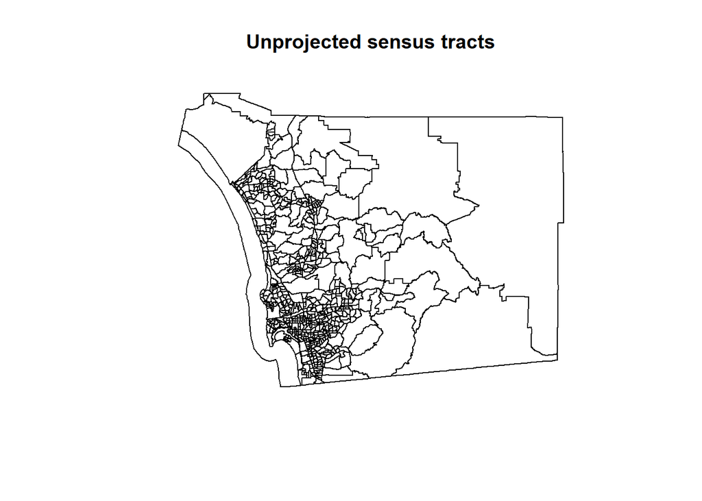

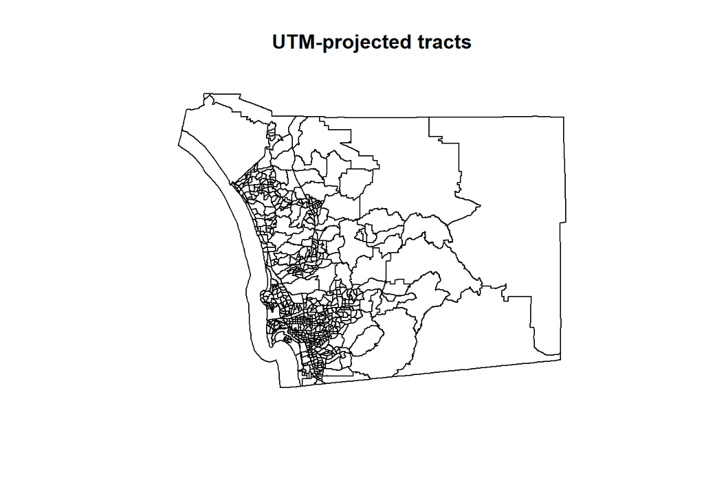

8. `areas_proj <- sapply(sd_tracts_proj@polygons, function(x) x@area)`
9. The column `ALAND` provided in `sd_tracts` data provides kind of different area information than `areas_proj`. The discripancies between the areas is so large (see mean of differences below). The differences in units or how people measure the area and transform the data might effect this discripancies.

```r
(areas_proj - as.numeric(sd_tracts@data$ALAND)) %>% mean
```

```
## [1] 1293433
```